# STA Final Project - COVID-19 Data Set

Oliver Yau, Su-Ting Tan, Koby Lieu, and Sihua Cai

# Setup

To begin the analysis of this data, we begin by importing the data and assigning the factors and response variables.

```r
COVID19 = read.table("COVID19.txt", header = T, sep = '\t')

# factors

sex = COVID19$Sex
age = COVID19$AgeGroup

# response variables

covid = as.numeric(COVID19$COVIDProp)
flu = (as.numeric(COVID19$InfluenzaProp))
pneumonia = as.numeric(COVID19$PneumoniaProp)
```

With two factors in this data set, we have decided that the two-way ANOVA model is appropriate.

# Plotting the Data & Initial Impressions

We are now going to plot the data on a dot plot, with the x-axis defined as the sex of the group (male or female) and the y-axis defined as the proportion of deaths from COVID-19. For the purposes of this analysis we acknowledge that the raw number of total deaths in a state plays a role in proper weighting of the proportions, but we will be excluding the total deaths for the time being.

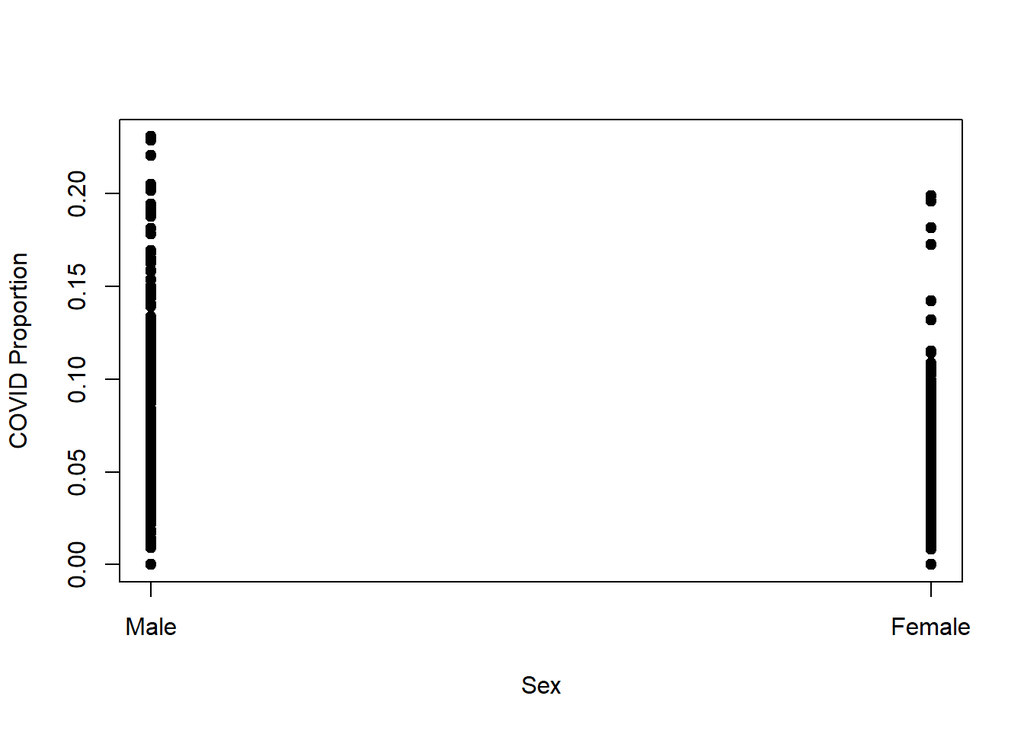

```r
# Sorting the Data by Sex to Graph it
level = 1*c(sex =='Male')+2*c(sex=='Female')

Male = rep(0, 364)
Female = rep(0, 364)

for(i in 0:51){
  for(j in 1:7){
    Male[7*i + j] = covid[14*i + j]
    Female[7*i+j] = covid[14*i+7+j]
  }
}

newsex = rep(0, 728)
newsex[1:364] = Male
newsex[365:728] = Female

# Plotting the data

plot(level, newsex, xaxt='n', main = '', pch=19, xlab = 'Sex', ylab = 'COVID Proportion')
axis(side = 1, at = c(1,2), labels = c('Male', 'Female'))
```

We add a jitter to have a better idea of the frequency.

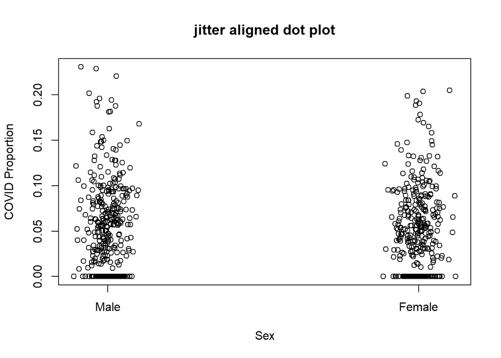

```r
level.jitter = level + rnorm(length(newsex), 0, sd=0.04)
plot(level.jitter,covid,xaxt = 'n',main = 'jitter aligned dot plot', xlab = 'Sex', ylab = 'COVID Proportion')
axis(side = 1, at = c(1,2), labels = c('Male', 'Female'))
```

Immediately, one can observe that males have more high death rates than females do, but we cannot conclude with certainty that there are differences currently. There is possibly an effect of sex on death rate from COVID-19.

Seeing as there are two factors, we also will now plot the data by age group, with the seven groups of age group on the x-axis and the proportion of deaths from COVID-19 on the y-axis.

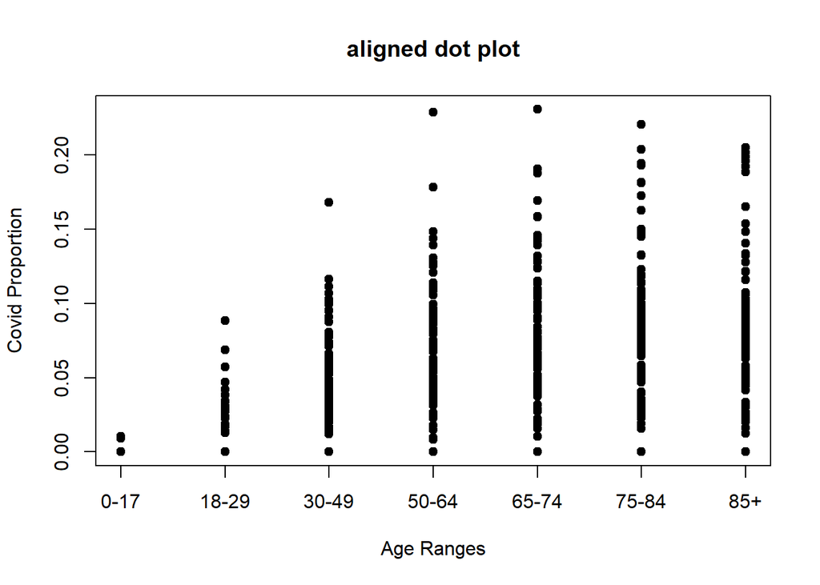

```r
level_age = 1*c(age=='0-17 years') + 2*c(age=='18-29 years') + 3*c(age=='30-49 years') + 4*c(age=='50-64 years') + 5*c(age=='65-74 years') + 6*c(age=='75-84 years') + 7*c(age=='85 years and over')

age_1 = rep(0,104)
age_2 = rep(0,104)
age_3 = rep(0,104)
age_4 = rep(0,104)
age_5 = rep(0,104)
age_6 = rep(0,104)
age_7 = rep(0,104)

for(i in 0:103){
  age_1[i] = covid[7*i+1]
  age_2[i] = covid[7*i+2]
  age_3[i] = covid[7*i+3]
  age_4[i] = covid[7*i+4]
  age_5[i] = covid[7*i+5]
  age_6[i] = covid[7*i+6]
  age_7[i] = covid[7*i+7]
}

new_age = rep(0, 728)
new_age[1:104] = age_1
new_age[105:208] = age_2
new_age[209:312] = age_3
new_age[313:416] = age_4
new_age[417:520] = age_5
new_age[521:624] = age_6
new_age[625:728] = age_7

agenames = c('0-17', '18-29', '30-49', '50-64', '65-74', '75-84', '85+')

plot(level_age, covid, xaxt='n', main = 'aligned dot plot', pch=19, xlab = 'Age Ranges', ylab = 'Covid Proportion')
axis(side = 1, at = c(1:7), labels = agenames)
```

We once again add a jitter to get a better idea of the frequency of death rates:

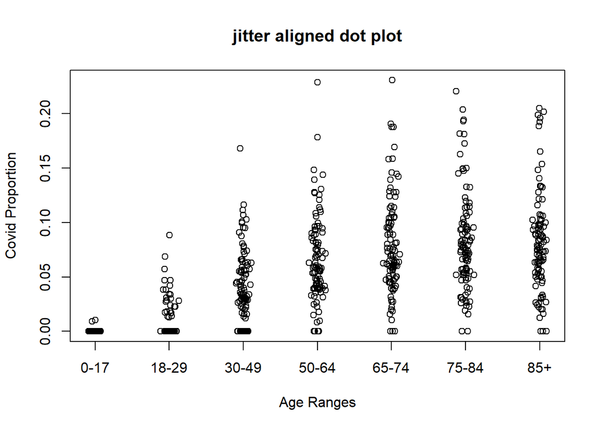

```r
level_age.jitter = level_age + rnorm(length(new_age), 0, sd=0.04)
plot(level_age.jitter,covid,xaxt = 'n',main = 'jitter aligned dot plot', xlab = 'Age Ranges', ylab = 'Covid Proportion')
axis(side = 1, at = c(1:7), labels = agenames)
```

From these plots we observe that younger people appear to die at a lesser rate than older people. There is possibly an effect of age on COVID-19.

# Parameter Estimation

Now that we’ve graphed the data to get an idea of what it looks like, we begin to calculate the important values of the data set: the means across all states for each combination of age group and sex for each of COVID-19, pneumonia, and influenza.

```r
# Parameter Estimation
a = 2
b = 7
n = 52

mu_covid = mean(covid)
mu_pneumonia = mean(pneumonia)
mu_influenza = mean(flu)


COVIDyij.bar = matrix(0, a, b)
Pneuyij.bar = matrix(0, a, b)
Fluyij.bar = matrix(0, a, b)
SexLabels = c("Male", "Female")
AgeLabels = c("0-17 years", "18-29 years", "30-49 years", "50-64 years", "65-74 years", "75-84 years", "85 years and over")
```

We use matrices to store the values of these parameter estimations. Three 2 x 7 matrices will account for the 2 levels of the sex variable and the 7 levels of the age group variable.

```r
for(i in 1:a){
  for(j in 1:b){
    COVIDyij.bar[i,j] = mean(covid[sex == SexLabels[i] & age == AgeLabels[j]])
  }
}

for(i in 1:a){
  for(j in 1:b){
    Fluyij.bar[i,j] = mean(flu[sex == SexLabels[i] & age == AgeLabels[j]])
  }
}

for(i in 1:a){
  for(j in 1:b){
    Pneuyij.bar[i,j] = mean(pneumonia[sex == SexLabels[i] & age == AgeLabels[j]])
  }
}
```

We will now calculate the alpha, beta, and gamma values for each of COVID-19, pneumonia, and influenza. Each respective disease will have a vector length 2 to store its alpha values and a vector length 2 to store its beta values. Each respective disease will also have its own 2 x 7 matrix to store its gamma values.

```r
#alpha
COVIDuA = apply(COVIDyij.bar, 1, mean)
COVIDalpha = COVIDuA - mu_covid

FluuA = apply(Fluyij.bar, 1, mean)
Flualpha = FluuA - mu_influenza

PneuuA = apply(Pneuyij.bar, 1, mean)
Pneualpha = PneuuA - mu_pneumonia



#beta
COVIDuB = apply(COVIDyij.bar, 2, mean)
COVIDbeta = COVIDuB - mu_covid

FluuB = apply(Fluyij.bar, 2, mean)
Flubeta = FluuB - mu_influenza

PneuuB = apply(Pneuyij.bar, 2, mean)
Pneubeta = PneuuB - mu_pneumonia



#gamma
COVIDgamma = matrix(0, a, b)
for(i in 1:a){
  for(j in 1:b){
    COVIDgamma[i, j] = COVIDyij.bar[i, j] - COVIDuA[i] - COVIDuB[j] + mu_covid
  }
}

Flugamma = matrix(0, a, b)
for(i in 1:a){
  for(j in 1:b){
    Flugamma[i, j] = Fluyij.bar[i, j] - FluuA[i] - FluuB[j] + mu_influenza
  }
}

Pneugamma = matrix(0, a, b)
for(i in 1:a){
  for(j in 1:b){
    Pneugamma[i, j] = Pneuyij.bar[i, j] - PneuuA[i] - PneuuB[j] + mu_pneumonia
  }
}
```

# Checking the Assumptions of the Two-Way ANOVA Model

As we know, there are assumptions that must be closely followed or otherwise noted when using the two-way ANOVA model. First, we need to check that the equal variance assumption by plotting the residual plots and looking for the variances among the data to be approximately equal. Then we plot the normal Q-Q plot for the residuals of each of the three diseases to check the normality assumption. We are starting first with COVID-19.

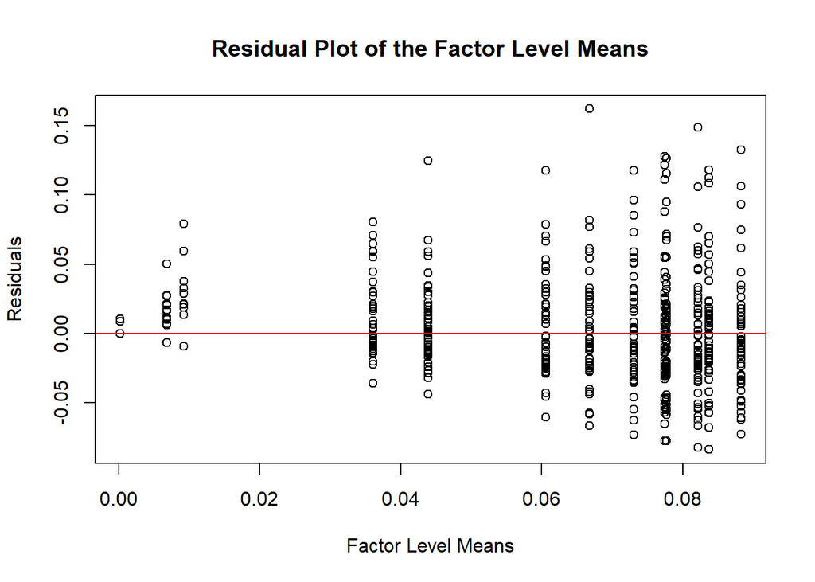

```r
# Model Assumptions

COVIDYhat = rep(0,length(time))
for(i in 1:a)
{
  for(j in 1:b)
  {
    COVIDYhat[sex == SexLabels[i] & age == AgeLabels[j]] = COVIDyij.bar[i,j]
  }
}
COVIDresidual = covid - COVIDYhat

plot(COVIDYhat, COVIDresidual, xlab = "Factor Level Means", main = "Residual Plot of the Factor Level Means", ylab = "Residuals")
abline(h=0,col='red')
```

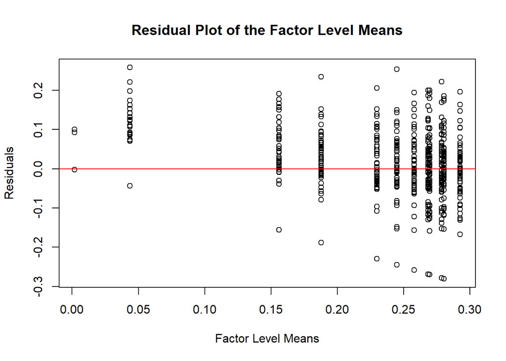

```r
# Transformation

covid = asin(sqrt(covid))

for(i in 1:a){
  for(j in 1:b){
    COVIDyij.bar[i,j] = mean(covid[sex == SexLabels[i] & age == AgeLabels[j]])
  }
}

COVIDYhat = rep(0,length(time))
for(i in 1:a)
{
  for(j in 1:b)
  {
    COVIDYhat[sex == SexLabels[i] & age == AgeLabels[j]] = COVIDyij.bar[i,j]
  }
}
COVIDresidual = covid - COVIDYhat

plot(COVIDYhat, COVIDresidual, xlab = "Factor Level Means", main = "Residual Plot of the Factor Level Means", ylab = "Residuals")
abline(h=0,col='red')
```

The residuals show better results (but still not ideal) as the variances are closer in range to one another.

Now we do the normal q-q plot for the normality assumption of COVID-19 data.

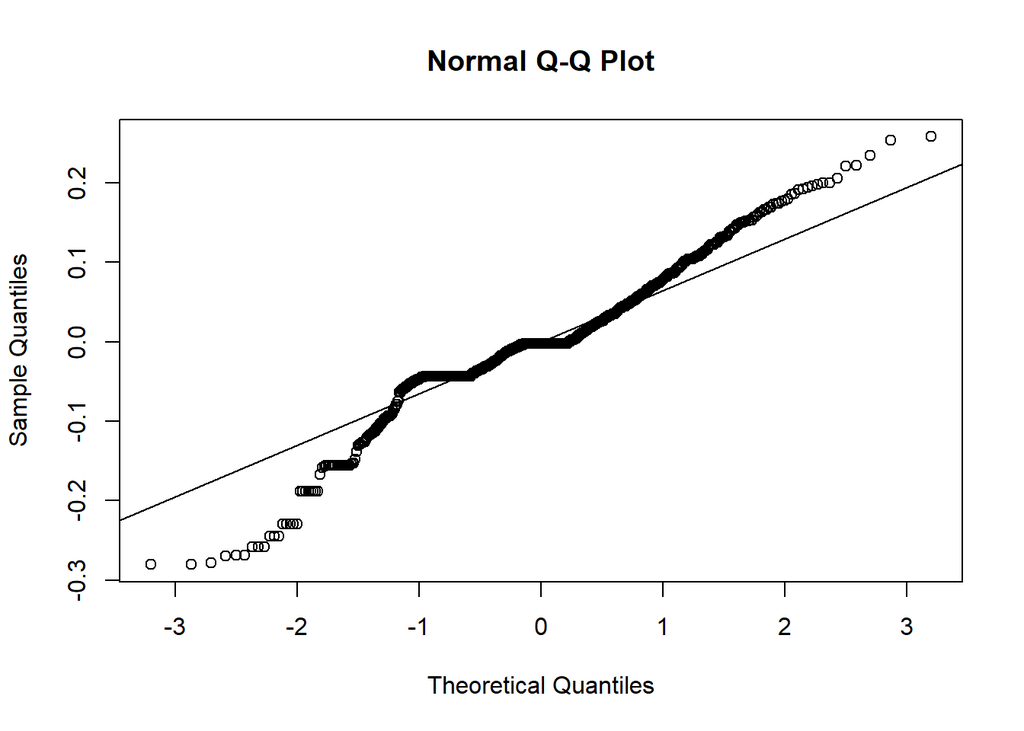

```r
qqnorm(COVIDresidual)
qqline(COVIDresidual)
```

We observe quite heavy tails on our normal Q-Q plot. The normality assumption is under question for the COVID-19 responses.

We now plot the residual plot for pneumonia.

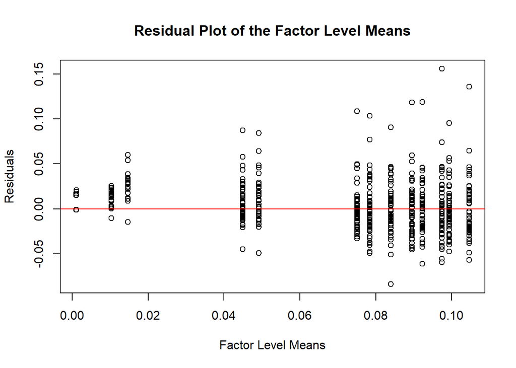

```r
PneuYhat = rep(0,length(time))
for(i in 1:a)
{
  for(j in 1:b)
  {
    PneuYhat[sex == SexLabels[i] & age == AgeLabels[j]] = Pneuyij.bar[i,j]
  }
}
Pneuresidual = pneumonia - PneuYhat

plot(PneuYhat, Pneuresidual, xlab = "Factor Level Means", main = "Residual Plot of the Factor Level Means", ylab = "Residuals")
abline(h=0,col='red')
```

It does not appear that the raw data follows the equal variance assumption, so we must transform it.

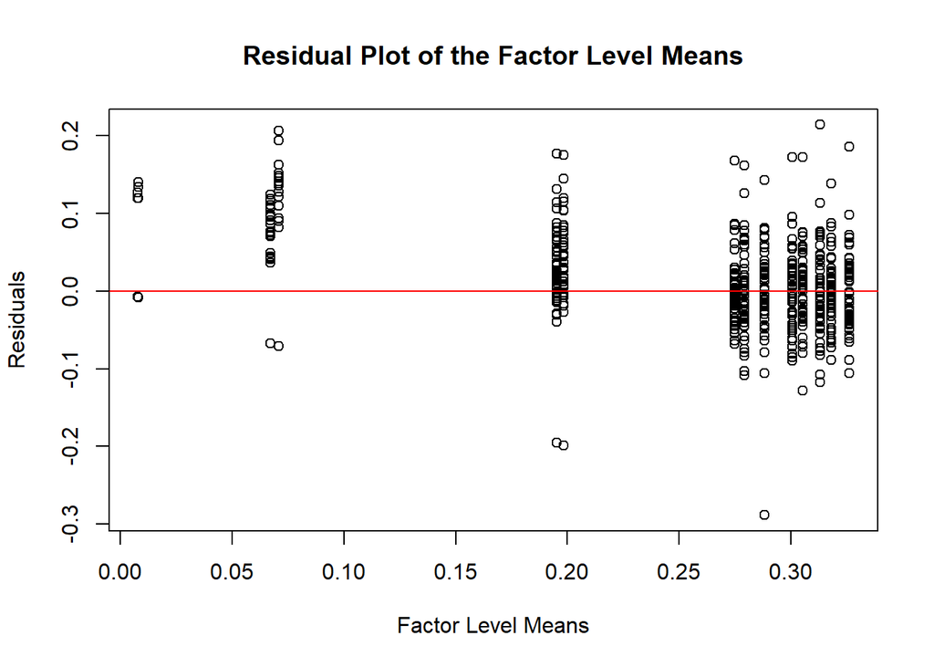

```r
# Transformation

pneumonia = asin(sqrt(pneumonia))

for(i in 1:a){
  for(j in 1:b){
    Pneuyij.bar[i,j] = mean(pneumonia[sex == SexLabels[i] & age == AgeLabels[j]])
  }
}

PneumoniaYhat = rep(0,length(time))
for(i in 1:a)
{
  for(j in 1:b)
  {
    PneumoniaYhat[sex == SexLabels[i] & age == AgeLabels[j]] = Pneuyij.bar[i,j]
  }
}
Pneuresidual = pneumonia - PneumoniaYhat

plot(PneumoniaYhat, Pneuresidual, xlab = "Factor Level Means", main = "Residual Plot of the Factor Level Means", ylab = "Residuals")
abline(h=0,col='red')
```

After transformation, the variances appear to be more equal than before (but still not ideal).

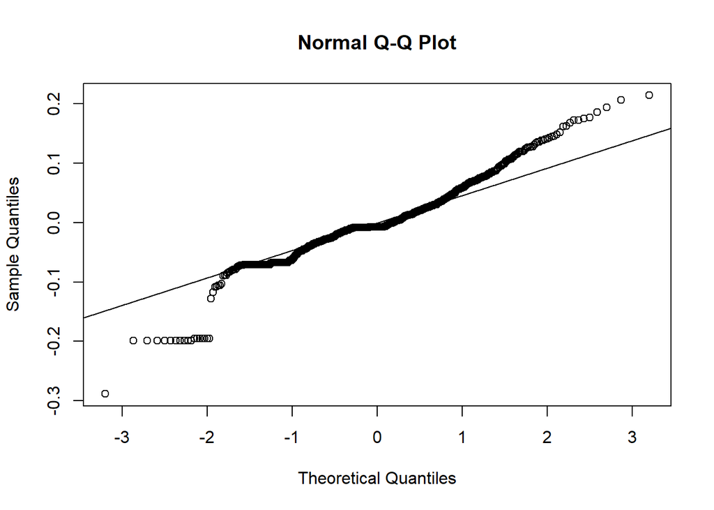

```r
qqnorm(Pneuresidual)
qqline(Pneuresidual)
```

The data does closely follow the qqnorm line for the most part, though with heavy tails. To some extent, the normality assumption for the pneumonia data may be under question.

We now plot the residual plot for influenza.

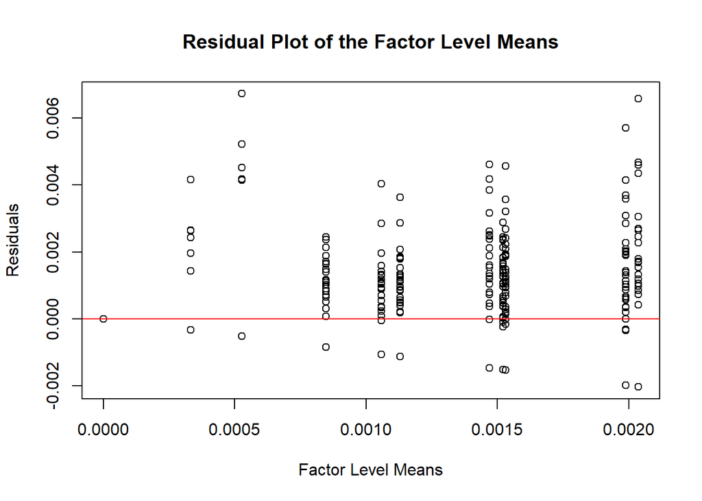

```r
FluYhat = rep(0,length(time))
for(i in 1:a)
{
  for(j in 1:b)
  {
    FluYhat[sex == SexLabels[i] & age == AgeLabels[j]] = Fluyij.bar[i,j]
  }
}
Fluresidual = flu - FluYhat

plot(FluYhat, Fluresidual, xlab = "Factor Level Means", main = "Residual Plot of the Factor Level Means", ylab = "Residuals")
abline(h=0,col='red')
```

It does not appear that the raw data follows the equal variance assumption, so we must transform it.

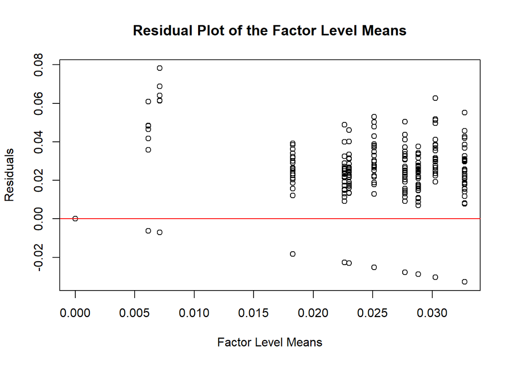

```r
# Transformation

flu = asin(sqrt(flu))

for(i in 1:a){
  for(j in 1:b){
    Fluyij.bar[i,j] = mean(flu[sex == SexLabels[i] & age == AgeLabels[j]])
  }
}

FluYhat = rep(0,length(time))
for(i in 1:a)
{
  for(j in 1:b)
  {
    FluYhat[sex == SexLabels[i] & age == AgeLabels[j]] = Fluyij.bar[i,j]
  }
}
Fluresidual = flu - FluYhat

plot(FluYhat, Fluresidual, xlab = "Factor Level Means", main = "Residual Plot of the Factor Level Means", ylab = "Residuals")
abline(h=0,col='red')
```

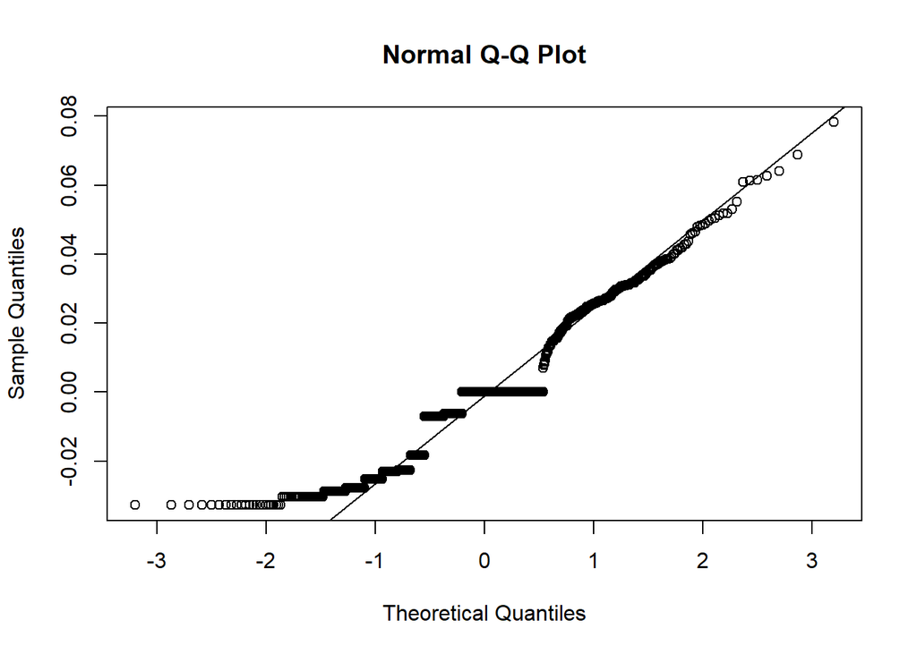

```r
qqnorm(Fluresidual)
qqline(Fluresidual)
```

There is major concern for the normality assumption with this influenza data set. The data does not follow the qqline very closely at all.

# Interaction of Age and Sex on Death Rates

We will now investigate the interaction of age and sex on the death rates for each particular disease with the interaction plots.

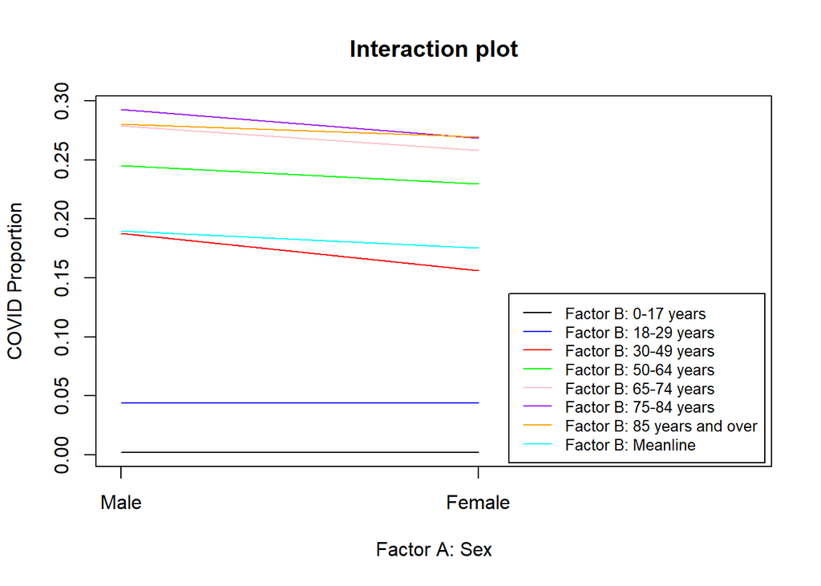

```r
## Interaction Plots

COVIDmean = apply(COVIDyij.bar, 1, mean)
plot(COVIDyij.bar[,1],xaxt = 'n',main = 'Interaction plot', pch=19, type="l", ylim=c(min(COVIDyij.bar),max(COVIDyij.bar)), xlim = c(1, 2.75), xlab="Factor A: Sex", ylab = "COVID Proportion")
axis(side = 1,at = c(1, 2),labels = c('Male','Female'))
points(COVIDyij.bar[,2], type="l", col="blue")
points(COVIDyij.bar[,3], type="l", col="red")
points(COVIDyij.bar[,4], type="l", col="green")
points(COVIDyij.bar[,5], type="l", col="pink")
points(COVIDyij.bar[,6], type="l", col="purple")
points(COVIDyij.bar[,7], type="l", col="orange")
points(COVIDmean, type="l", col="cyan")
legend("bottomright", legend=c("Factor B: 0-17 years", "Factor B: 18-29 years", "Factor B: 30-49 years",
                               "Factor B: 50-64 years", "Factor B: 65-74 years", "Factor B: 75-84 years",
                               "Factor B: 85 years and over", "Factor B: Meanline"),
       col=c("black","blue", "red", "green", "pink", "purple", "orange", "cyan"), lty=1 , inset = .01, cex = 0.8)
```

There are a few lines that are not parallel, so we have reason to believe there may be an interaction effect based on the plot.

Here is the interaction plot of the pneumonia data.

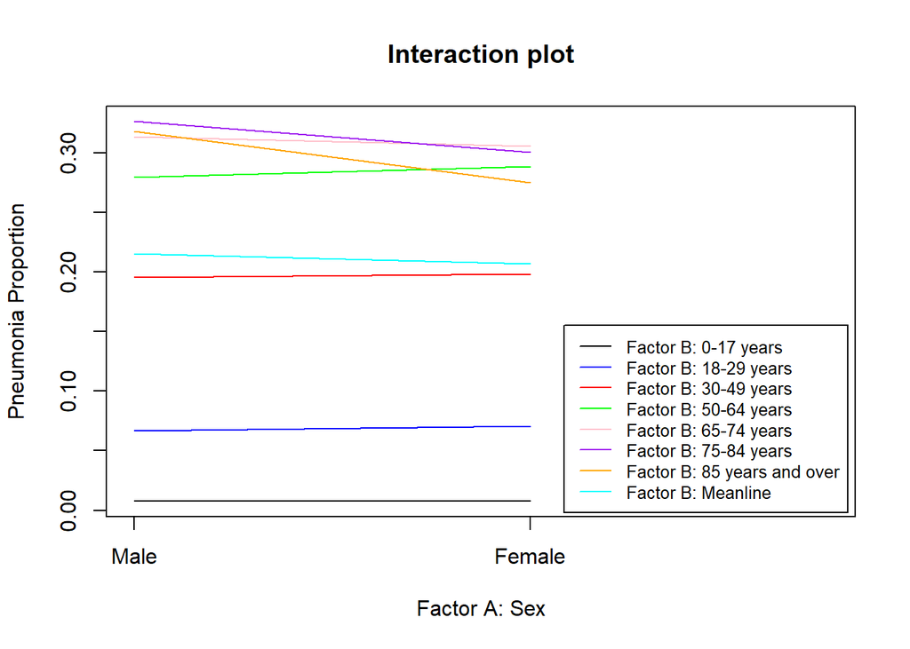

```r
Pneumean = apply(Pneuyij.bar, 1, mean)
plot(Pneuyij.bar[,1],xaxt = 'n',main = 'Interaction plot', pch=19, type="l", ylim=c(min(Pneuyij.bar),max(Pneuyij.bar)), xlim = c(1, 2.75), xlab="Factor A: Sex", ylab = "Pneumonia Proportion")
axis(side = 1,at = c(1, 2),labels = c('Male','Female'))
points(Pneuyij.bar[,2], type="l", col="blue")
points(Pneuyij.bar[,3], type="l", col="red")
points(Pneuyij.bar[,4], type="l", col="green")
points(Pneuyij.bar[,5], type="l", col="pink")
points(Pneuyij.bar[,6], type="l", col="purple")
points(Pneuyij.bar[,7], type="l", col="orange")
points(Pneumean, type="l", col="cyan")
legend("bottomright", legend=c("Factor B: 0-17 years", "Factor B: 18-29 years", "Factor B: 30-49 years",
                               "Factor B: 50-64 years", "Factor B: 65-74 years", "Factor B: 75-84 years",
                               "Factor B: 85 years and over", "Factor B: Meanline"), col=c("black","blue", "red", "green", "pink", "purple", "orange", "cyan"), lty=1 , inset = .01, cex = 0.8)
```

There does seem to be an interaction effect, as not all the lines appear to be parallel (with some intersections).

Here is the interaction plot for influenza:

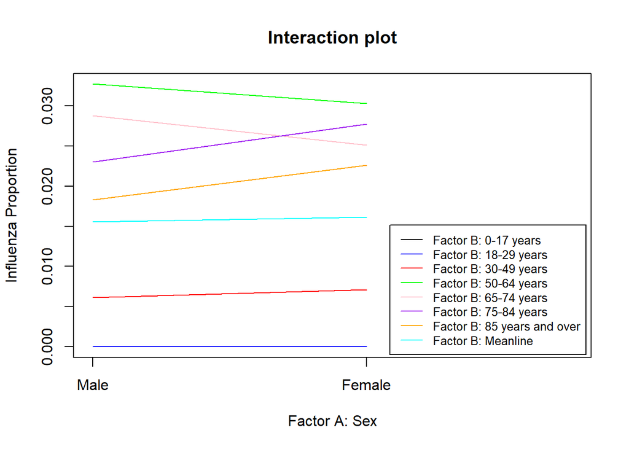

```r
Flumean = apply(Fluyij.bar, 1, mean)
plot(Fluyij.bar[,1],xaxt = 'n',main = 'Interaction plot', pch=19, type="l", ylim=c(min(Fluyij.bar),max(Fluyij.bar)), xlim = c(1, 2.75), xlab="Factor A: Sex", ylab = "Influenza Proportion")
axis(side = 1,at = c(1, 2),labels = c('Male','Female'))
points(Fluyij.bar[,2], type="l", col="blue")
points(Fluyij.bar[,3], type="l", col="red")
points(Fluyij.bar[,4], type="l", col="green")
points(Fluyij.bar[,5], type="l", col="pink")
points(Fluyij.bar[,6], type="l", col="purple")
points(Fluyij.bar[,7], type="l", col="orange")
points(Flumean, type="l", col="cyan")
legend("bottomright", legend=c("Factor B: 0-17 years", "Factor B: 18-29 years", "Factor B: 30-49 years",
                               "Factor B: 50-64 years", "Factor B: 65-74 years", "Factor B: 75-84 years",
                               "Factor B: 85 years and over", "Factor B: Meanline"), col=c("black","blue", "red", "green", "pink", "purple", "orange", "cyan"), lty=1 , inset = .01, cex = 0.8)
```

Visually there does seem to be an interaction, as not all the lines are parallel.

# ANOVA Tables

We will now compute the values of the ANOVA table for each of COVID-19, pneumonia, and influenza.

```r
## ANOVA table

# Degrees of Freedom

df_a = a-1
df_b = b-1
df_ab = (a-1)*(b-1)
df_e = a*b*(n-1)
df_total = (n*a*b)-1



#SSA
COVIDmA = rep(0, 2)
COVIDmA[1] = mean(COVIDyij.bar[1,])
COVIDmA[2] = mean(COVIDyij.bar[2,])

COVIDSSA = n*b*sum((COVIDmA - mu_covid)^2)
COVIDMSA = COVIDSSA/df_a

PneumA = rep(0, 2)
PneumA[1] = mean(Pneuyij.bar[1,])
PneumA[2] = mean(Pneuyij.bar[2,])

PneuSSA = n*b*sum((PneumA - mu_pneumonia)^2)
PneuMSA = PneuSSA/df_a

FlumA = rep(0, 2)
FlumA[1] = mean(Fluyij.bar[1,])
FlumA[2] = mean(Fluyij.bar[2,])

FluSSA = n*b*sum((FlumA - mu_influenza)^2)
FluMSA = FluSSA/df_a



##SSB
COVIDmB = rep(0, 7)
COVIDmB[1] = mean(COVIDyij.bar[, 1])
COVIDmB[2] = mean(COVIDyij.bar[, 2])
COVIDmB[3] = mean(COVIDyij.bar[, 3])
COVIDmB[4] = mean(COVIDyij.bar[, 4])
COVIDmB[5] = mean(COVIDyij.bar[, 5])
COVIDmB[6] = mean(COVIDyij.bar[, 6])
COVIDmB[7] = mean(COVIDyij.bar[, 7])
COVIDSSB = n*a*sum((COVIDmB - mu_covid)^2)
COVIDMSB = COVIDSSB/df_b


PneumB = rep(0, 7)
PneumB[1] = mean(Pneuyij.bar[, 1])
PneumB[2] = mean(Pneuyij.bar[, 2])
PneumB[3] = mean(Pneuyij.bar[, 3])
PneumB[4] = mean(Pneuyij.bar[, 4])
PneumB[5] = mean(Pneuyij.bar[, 5])
PneumB[6] = mean(Pneuyij.bar[, 6])
PneumB[7] = mean(Pneuyij.bar[, 7])
PneuSSB = n*a*sum((PneumB - mu_pneumonia)^2)
PneuMSB = PneuSSB/df_b


FlumB = rep(0, 7)
FlumB[1] = mean(Fluyij.bar[, 1])
FlumB[2] = mean(Fluyij.bar[, 2])
FlumB[3] = mean(Fluyij.bar[, 3])
FlumB[4] = mean(Fluyij.bar[, 4])
FlumB[5] = mean(Fluyij.bar[, 5])
FlumB[6] = mean(Fluyij.bar[, 6])
FlumB[7] = mean(Fluyij.bar[, 7])
FluSSB = n*a*sum((FlumB - mu_influenza)^2)
FluMSB = FluSSB/df_b



##SSAB
COVIDABmat = matrix(0, a, b)
for (i in 1:a){
  for (j in 1:b){
    COVIDABmat[i, j] = (COVIDyij.bar[i,j] - COVIDmA[i] - COVIDmB[j] + mu_covid)^2
  }
}

COVIDSSAB = n*sum(COVIDABmat)
COVIDMSAB = COVIDSSAB/df_ab



PneuABmat = matrix(0, a, b)
for (i in 1:a){
  for (j in 1:b){
    PneuABmat[i, j] = (Pneuyij.bar[i,j] - PneumA[i] - PneumB[j] + mu_pneumonia)^2
  }
}

PneuSSAB = n*sum(PneuABmat)
PneuMSAB = PneuSSAB/df_ab



FluABmat = matrix(0, a, b)
for (i in 1:a){
  for (j in 1:b){
    FluABmat[i, j] = (Fluyij.bar[i,j] - FlumA[i] - FlumB[j] + mu_influenza)^2
  }
}

FluSSAB = n*sum(FluABmat)
FluMSAB = FluSSAB/df_ab



##SSE
COVIDError = matrix(0, a, b)
for(i in 1:a){
  for(j in 1:b){
    COVIDError[i, j] = sum((covid[sex == SexLabels[i] & age == AgeLabels[j]] - COVIDyij.bar[i, j])^2)
  }
}

COVIDSSE = sum(COVIDError)
COVIDMSE = COVIDSSE/df_e


PneuError = matrix(0, a, b)
for(i in 1:a){
  for(j in 1:b){
    PneuError[i, j] = sum((pneumonia[sex == SexLabels[i] & age == AgeLabels[j]] - Pneuyij.bar[i, j])^2)
  }
}

PneuSSE = sum(PneuError)
PneuMSE = PneuSSE/df_e



FluError = matrix(0, a, b)
for(i in 1:a){
  for(j in 1:b){
    FluError[i, j] = sum((flu[sex == SexLabels[i] & age == AgeLabels[j]] - Fluyij.bar[i, j])^2)
  }
}

FluSSE = sum(FluError)
FluMSE = FluSSE/df_e


##Totals

COVIDSSTO = COVIDSSA + COVIDSSB + COVIDSSAB + COVIDSSE
PneuSSTO = PneuSSA + PneuSSB + PneuSSAB + PneuSSE
FluSSTO = FluSSA + FluSSB + FluSSAB + FluSSE

COVIDMSTO = COVIDMSA + COVIDMSB + COVIDMSAB + COVIDMSE
PneuMSTO = PneuMSA + PneuMSB + PneuMSAB + PneuMSE
FluMSTO = FluMSA + FluMSB + FluMSAB + FluMSE
```

We present the ANOVA tables one by one, first with COVID-19 data and then the pneumonia and flu to compare.

Here is the COVID-19 ANOVA table:

```r
require(pander)
mydat = data.frame(
  'Source of Variation' = c('Factor A', 'Factor B', 'AB Interaction', 'Error', 'Total'),
  'Sum of Squares' = c(COVIDSSA, COVIDSSB, COVIDSSAB, COVIDSSE, COVIDSSTO),
  'Degrees of Freedom' = c(df_a, df_b, df_ab, df_e, df_total),
  'Mean of Squares' = c(COVIDMSA, COVIDMSB, COVIDMSAB, COVIDMSE, COVIDMSTO))
colnames(mydat) = c('Source of Variation', 'Least Squares Estimates', 'Degrees of Freedom', 'Mean of Squares')
panderOptions('table.split.table', Inf)
pander(pandoc.table(mydat),style = 'rmarkdown')
```

| Source of Variation | Least Squares Estimates | Degrees of Freedom | Mean of Squares |
| --- | --- | --- | --- |
| Factor A | 12.77 | 1 | 12.77 |
| Factor B | 21.11 | 6 | 3.519 |
| AB Interaction | 12.76 | 6 | 2.126 |
| Error | 5.237 | 714 | 0.007335 |
| Total | 51.88 | 727 | 18.43 |

Here is the pneumonia ANOVA table:

```r
mydat = data.frame(
  'Source of Variation' = c('Factor A', 'Factor B', 'AB Interaction', 'Error', 'Total'),
  'Sum of Squares' = c(PneuSSA, PneuSSB, PneuSSAB, PneuSSE, PneuSSTO),
  'Degrees of Freedom' = c(df_a, df_b, df_ab, df_e, df_total),
  'Mean of Squares' = c(PneuMSA, PneuMSB, PneuMSAB, PneuMSE, PneuMSTO))
colnames(mydat) = c('Source of Variation', 'Least Squares Estimates', 'Degrees of Freedom', 'Mean of Squares')
panderOptions('table.split.table', Inf)
pander(pandoc.table(mydat),style = 'rmarkdown')
```

| Source of Variation | Least Squares Estimates | Degrees of Freedom | Mean of Squares |
| --- | --- | --- | --- |
| Factor A | 16.56 | 1 | 16.56 |
| Factor B | 26.37 | 6 | 4.395 |
| AB Interaction | 16.61 | 6 | 2.768 |
| Error | 2.98 | 714 | 0.004174 |
| Total | 62.52 | 727 | 23.73 |

Here is the influenza table:

```r
mydat = data.frame(
  'Source of Variation' = c('Factor A', 'Factor B', 'AB Interaction', 'Error', 'Total'),
  'Sum of Squares' = c(FluSSA, FluSSB, FluSSAB, FluSSE, FluSSTO),
  'Degrees of Freedom' = c(df_a, df_b, df_ab, df_e, df_total),
  'Mean of Squares' = c(FluMSA, FluMSB, FluMSAB, FluMSE, FluMSTO))
colnames(mydat) = c('Source of Variation', 'Least Squares Estimates', 'Degrees of Freedom', 'Mean of Squares')
panderOptions('table.split.table', Inf)
pander(pandoc.table(mydat),style = 'rmarkdown')
```

| Source of Variation | Least Squares Estimates | Degrees of Freedom | Mean of Squares |
| --- | --- | --- | --- |
| Factor A | 0.1628 | 1 | 0.1628 |
| Factor B | 0.2738 | 6 | 0.04563 |
| AB Interaction | 0.1643 | 6 | 0.02738 |
| Error | 0.3526 | 714 | 0.0004938 |
| Total | 0.9535 | 727 | 0.2363 |

# Tests for Interaction, Factor A, and Factor B effects

We now test for interaction of sex and age on each of the death rates for COVID-19, pneumonia, and influenza respectively with $\alpha = 0.05$. The following decision rules and hypotheses apply to all of COVID-19 data, pneumonia data, and influenza data.

Test for Interaction effects:

$H_0:$ There is no interaction effect between the factors.

$H_A:$ There is an interaction effect between the factors.

Test statistic: $F^* = \frac{MSAB}{MSE} = \frac{(\frac{SSAB}{(a-1)(b-1)})}{(\frac{SSE}{(nab-ab)})}$

Decision rule: Reject the no-interaction effect null hypothesis if $F^* > F(0.95, 6, 714)$.

Test for Factor A effects:

$H_0:$ There is no Factor A effect.

$H_A:$ There is a Factor A effect.

Test Statistic: $F^* = \frac{MSA}{MSE} = \frac{(\frac{SSA}{a-1})}{(\frac{SSE}{nab-ab})}$

Decision rule: Reject the no-Factor A effect null hypothesis if $F^* > F(0.95, 1, 714)$

Test for Factor B effects:

$H_0:$ There is no Factor B effect.

$H_A:$ There is a Factor B effect.

Test Statistic: $F^* = \frac{MSB}{MSE} = \frac{(\frac{SSB}{b-1})}{(\frac{SSE}{nab-ab})}$

Decision rule: Reject the no-Factor B effect null hypothesis if $F^* > F(0.95, 6, 714)$

Here we test for interaction, Factor A effect, and Factor B effect in COVID data.

```r
## Hypothesis Testing - COVID-19 Data

## Interaction Effect

COVID_TestStat_int = COVIDMSAB/COVIDMSE
CritVal_int = qf(0.95, (a-1)*(b-1), a*b*(n-1))
```

```r
# Factor A
COVID_TestStat_A = COVIDMSA/COVIDMSE
CritVal_A = qf(0.95, a-1, a*b*(n-1))

# Factor B

COVID_TestStat_B = COVIDMSB/COVIDMSE
CritVal_B = qf(0.95, b-1, a*b*(n-1))

mydat = data.frame('test stat' = c(COVID_TestStat_A, COVID_TestStat_B, COVID_TestStat_int),
                   'crit val' = c(CritVal_A, CritVal_B, CritVal_int))
colnames(mydat) = c('Test Statistic', 'Critical Value')
rownames(mydat) = c('Factor A', 'Factor B', 'Interaction')
panderOptions('table.split.table', Inf)
pander(pandoc.table(mydat),style = 'rmarkdown')
```

|  | Test Statistic | Critical Value |
| --- | --- | --- |
| **Factor A** | 1742 | 3.855 |
| **Factor B** | 479.8 | 2.111 |
| **Interaction** | 289.9 | 2.111 |

From these tests, we can conclude that:

- With a test statistic of 1741.6597231 and a critical value of 3.8545156, we have sufficient evidence to prove that there is a Factor A effect of sex on COVID-19 death rates.
- With a test statistic of 479.7803155 and a critical value of 2.1112599, we have sufficient evidence to prove that there is a Factor B effect of age on COVID-19 death rates.
- With a test statistic of 289.9083907 and a critical value of 2.1112599, we have sufficient evidence to prove that there is an interaction effect between sex and age on COVID-19 death rates.

Here we test for interaction effect, Factor A effect, and Factor B effect in pneumonia data.

```r
# PNEUMONIA

## Interaction Effect

Pneu_TestStat_int = PneuMSAB/PneuMSE

Pneu_TestStat_A = PneuMSA/PneuMSE

## Factor B

Pneu_TestStat_B = PneuMSB/PneuMSE

mydat = data.frame('test stat' = c(Pneu_TestStat_A, Pneu_TestStat_B, Pneu_TestStat_int),
                   'crit val' = c(CritVal_A, CritVal_B, CritVal_int))
colnames(mydat) = c('Test Statistic', 'Critical Value')
rownames(mydat) = c('Factor A', 'Factor B', 'Interaction')
panderOptions('table.split.table', Inf)
pander(pandoc.table(mydat),style = 'rmarkdown')
```

|  | Test Statistic | Critical Value |
| --- | --- | --- |
| **Factor A** | 3968 | 3.855 |
| **Factor B** | 1053 | 2.111 |
| **Interaction** | 663 | 2.111 |

From these tests, we can conclude that:

- With a test statistic of 3967.9848703 and a critical value of 3.8545156, we have sufficient evidence to prove that there is a Factor A effect of sex on pneumonia death rates.
- With a test statistic of 1052.8887713 and a critical value of 2.1112599, we have sufficient evidence to prove that there is a Factor B effect of age on pneumonia death rates.
- With a test statistic of 663.0445839 and a critical value of 2.1112599, we have sufficient evidence to prove that there is an interaction effect between sex and age on pneumonia death rates.

Here we test for interaction effect, Factor A effect, and Factor B effect in influenza data.

```r
## Interaction Effect

Flu_TestStat_int = FluMSAB/FluMSE

# FLU
Flu_TestStat_A = FluMSA/FluMSE

# Factor B

Flu_TestStat_B = FluMSB/FluMSE


mydat = data.frame('test stat' = c(Flu_TestStat_A, Flu_TestStat_B, Flu_TestStat_int),
                   'crit val' = c(CritVal_A, CritVal_B, CritVal_int))
colnames(mydat) = c('Test Statistic', 'Critical Value')
rownames(mydat) = c('Factor A', 'Factor B', 'Interaction')
panderOptions('table.split.table', Inf)
pander(pandoc.table(mydat),style = 'rmarkdown')
```

|  | Test Statistic | Critical Value |
| --- | --- | --- |
| **Factor A** | 329.7 | 3.855 |
| **Factor B** | 92.42 | 2.111 |
| **Interaction** | 55.46 | 2.111 |

From these tests, we can conclude that:

- With a test statistic of 329.7451556 and a critical value of 3.8545156, we have sufficient evidence to prove that there is a Factor A effect of sex on influenza death rates.
- With a test statistic of 92.4170936 and a critical value of 2.1112599, we have sufficient evidence to prove that there is a Factor B effect of age on influenza death rates.
- With a test statistic of 55.4590669 and a critical value of 2.1112599, we have sufficient evidence to prove that there is an interaction effect between sex and age on influenza death rates.

# Comparison of COVID-19 and Influenza

We will conduct 95% confidence intervals for the COVID-19, pneumonia, and influenza. For these intervals we use an alpha level of 0.05 ($\alpha = 0.05$).

```r
# Assign point estimators

# Male, COVID-19

u_M_0_17_COVID = COVIDyij.bar[1,1]
u_M_18_29_COVID = COVIDyij.bar[1,2]
u_M_30_49_COVID = COVIDyij.bar[1,3]
u_M_50_64_COVID = COVIDyij.bar[1,4]
u_M_65_74_COVID = COVIDyij.bar[1,5]
u_M_75_84_COVID = COVIDyij.bar[1,6]
u_M_85_plus_COVID = COVIDyij.bar[1,7]

# Female, COVID-19

u_F_0_17_COVID = COVIDyij.bar[2,1]
u_F_18_29_COVID = COVIDyij.bar[2,2]
u_F_30_49_COVID = COVIDyij.bar[2,3]
u_F_50_64_COVID = COVIDyij.bar[2,4]
u_F_65_74_COVID = COVIDyij.bar[2,5]
u_F_75_84_COVID = COVIDyij.bar[2,6]
u_F_85_plus_COVID = COVIDyij.bar[2,7]

# Male, pneumonia

u_M_0_17_pneumonia = Pneuyij.bar[1,1]
u_M_18_29_pneumonia = Pneuyij.bar[1,2]
u_M_30_49_pneumonia = Pneuyij.bar[1,3]
u_M_50_64_pneumonia = Pneuyij.bar[1,4]
u_M_65_74_pneumonia = Pneuyij.bar[1,5]
u_M_75_84_pneumonia = Pneuyij.bar[1,6]
u_M_85_plus_pneumonia = Pneuyij.bar[1,7]

# Female, pneumonia

u_F_0_17_pneumonia = Pneuyij.bar[2,1]
u_F_18_29_pneumonia = Pneuyij.bar[2,2]
u_F_30_49_pneumonia = Pneuyij.bar[2,3]
u_F_50_64_pneumonia = Pneuyij.bar[2,4]
u_F_65_74_pneumonia = Pneuyij.bar[2,5]
u_F_75_84_pneumonia = Pneuyij.bar[2,6]
u_F_85_plus_pneumonia = Pneuyij.bar[2,7]

# Male, influenza

u_M_0_17_influenza = Fluyij.bar[1,1]
u_M_18_29_influenza = Fluyij.bar[1,2]
u_M_30_49_influenza = Fluyij.bar[1,3]
u_M_50_64_influenza = Fluyij.bar[1,4]
u_M_65_74_influenza = Fluyij.bar[1,5]
u_M_75_84_influenza = Fluyij.bar[1,6]
u_M_85_plus_influenza = Fluyij.bar[1,7]

# Female, influenza

u_F_0_17_influenza = Fluyij.bar[2,1]
u_F_18_29_influenza = Fluyij.bar[2,2]
u_F_30_49_influenza = Fluyij.bar[2,3]
u_F_50_64_influenza = Fluyij.bar[2,4]
u_F_65_74_influenza = Fluyij.bar[2,5]
u_F_75_84_influenza = Fluyij.bar[2,6]
u_F_85_plus_influenza = Fluyij.bar[2,7]



# Standard Errors

se_covid = sqrt(COVIDMSE/n)
se_pneumonia = sqrt(PneuMSE/n)
se_influenza = sqrt(FluMSE/n)



# Multiplier

multiplier = qt(1-(0.05/2),df=a*b*(n-1))
```

Here is the table of confidence intervals for the death rates of males for various age groups due to COVID-19.

```r
# Confidence Intervals

# Male, COVID-19

CI_M_0_17_COVID = c(u_M_0_17_COVID - multiplier * se_covid, u_M_0_17_COVID + multiplier * se_covid)
CI_M_18_29_COVID = c(u_M_18_29_COVID - multiplier * se_covid, u_M_18_29_COVID + multiplier * se_covid)
CI_M_30_49_COVID = c(u_M_30_49_COVID - multiplier * se_covid, u_M_30_49_COVID + multiplier * se_covid)
CI_M_50_64_COVID = c(u_M_50_64_COVID - multiplier * se_covid, u_M_50_64_COVID + multiplier * se_covid)
CI_M_65_74_COVID = c(u_M_65_74_COVID - multiplier * se_covid, u_M_65_74_COVID + multiplier * se_covid)
CI_M_75_84_COVID = c(u_M_75_84_COVID - multiplier * se_covid, u_M_75_84_COVID + multiplier * se_covid)
CI_M_85_plus_COVID = c(u_M_85_plus_COVID - multiplier * se_covid, u_M_85_plus_COVID + multiplier * se_covid)

mydat = data.frame(
  'Lower Bound' = c(CI_M_0_17_COVID[1], CI_M_18_29_COVID[1], CI_M_30_49_COVID[1], CI_M_50_64_COVID[1], CI_M_65_74_COVID[1], CI_M_75_84_COVID[1], CI_M_85_plus_COVID[1]),
  'Upper Bound' = c(CI_M_0_17_COVID[2], CI_M_18_29_COVID[2], CI_M_30_49_COVID[2], CI_M_50_64_COVID[2], CI_M_65_74_COVID[2], CI_M_75_84_COVID[2], CI_M_85_plus_COVID[2]))
colnames(mydat) = c('Lower Bound', 'Upper Bound')
rownames(mydat) = c('Ages 0-17', 'Ages 18-29', 'Ages 30-49', 'Ages 50-64', 'Ages 65-74', 'Ages 75-84', 'Ages 85+')
panderOptions('table.split.table', Inf)
pander(pandoc.table(mydat),style = 'rmarkdown')
```

|  | Lower Bound | Upper Bound |
| --- | --- | --- |
| **Ages 0-17** | -0.02149 | 0.02514 |
| **Ages 18-29** | 0.0203 | 0.06693 |
| **Ages 30-49** | 0.1646 | 0.2113 |
| **Ages 50-64** | 0.2217 | 0.2683 |
| **Ages 65-74** | 0.2553 | 0.302 |
| **Ages 75-84** | 0.2693 | 0.316 |
| **Ages 85+** | 0.2571 | 0.3037 |

Here is the table of confidence intervals for the death rates of females for various age groups due to COVID-19.

```r
# Female, COVID-19

CI_F_0_17_COVID = c(u_F_0_17_COVID - multiplier * se_covid, u_F_0_17_COVID + multiplier * se_covid)
CI_F_18_29_COVID = c(u_F_18_29_COVID - multiplier * se_covid, u_F_18_29_COVID + multiplier * se_covid)
CI_F_30_49_COVID = c(u_F_30_49_COVID - multiplier * se_covid, u_F_30_49_COVID + multiplier * se_covid)
CI_F_50_64_COVID = c(u_F_50_64_COVID - multiplier * se_covid, u_F_50_64_COVID + multiplier * se_covid)
CI_F_65_74_COVID = c(u_F_65_74_COVID - multiplier * se_covid, u_F_65_74_COVID + multiplier * se_covid)
CI_F_75_84_COVID = c(u_F_75_84_COVID - multiplier * se_covid, u_F_75_84_COVID + multiplier * se_covid)
CI_F_85_plus_COVID = c(u_F_85_plus_COVID - multiplier * se_covid, u_F_85_plus_COVID + multiplier * se_covid)

mydat = data.frame(
  'Lower Bound' = c(CI_F_0_17_COVID[1], CI_F_18_29_COVID[1], CI_F_30_49_COVID[1], CI_F_50_64_COVID[1], CI_F_65_74_COVID[1], CI_F_75_84_COVID[1], CI_F_85_plus_COVID[1]),
  'Upper Bound' = c(CI_F_0_17_COVID[2], CI_F_18_29_COVID[2], CI_F_30_49_COVID[2], CI_F_50_64_COVID[2], CI_F_65_74_COVID[2], CI_F_75_84_COVID[2], CI_F_85_plus_COVID[2]))
colnames(mydat) = c('Lower Bound', 'Upper Bound')
rownames(mydat) = c('Ages 0-17', 'Ages 18-29', 'Ages 30-49', 'Ages 50-64', 'Ages 65-74', 'Ages 75-84', 'Ages 85+')
panderOptions('table.split.table', Inf)
pander(pandoc.table(mydat),style = 'rmarkdown')
```

|  | Lower Bound | Upper Bound |
| --- | --- | --- |
| **Ages 0-17** | -0.02135 | 0.02529 |
| **Ages 18-29** | 0.02039 | 0.06703 |
| **Ages 30-49** | 0.1327 | 0.1793 |
| **Ages 50-64** | 0.2065 | 0.2531 |
| **Ages 65-74** | 0.2347 | 0.2814 |
| **Ages 75-84** | 0.2453 | 0.292 |
| **Ages 85+** | 0.2462 | 0.2928 |

*Note*: For the practical implications of the intervals for males ages 0-17 and females ages 0-17, it is impossible to have a negative death rate so the natural lower bound is 0% death rate.

### Analysis of Age and Sex Differences on COVID-19 Death Rate

We have evidence that suggests:

- The bounds of the confidence intervals generally seem to be increasing as people get older across both males and females. Our analysis shows us that older people die from COVID-19 at a higher proportion than younger people. However, this does not mean that the true death rate for each age group is necessarily greater than the previous age group’s death rate, as consecutive age group confidence intervals have overlap, meaning that the true death rate for one age-sex combination due to COVID-19 could be less than, greater than, or equal to the true death rate for another age-sex combination due to COVID-19.
- The increasing change in death rate as individuals get older stabilizes when individuals are 65 or older. The average death rates of the last three age groups have minimal differences between them, as all three confidence intervals overlap for a large section of each interval.
- Across a majority of these COVID-19 intervals, males die from COVID-19 at a very slightly higher proportion than females die from COVID-19. However, this slight difference alone is noted but not enough evidence on its own to signify a significant Factor A effect (sex) on COVID-19 death rates.
- For both males and females, the biggest increase in death rates is between the age groups of Ages 18-29 and Ages 30-49.

Here is the table of confidence intervals for the death rates of males for various age groups due to pneumonia.

```r
# Male, pneumonia

CI_M_0_17_pneumonia = c(u_M_0_17_pneumonia - multiplier * se_pneumonia, u_M_0_17_pneumonia + multiplier * se_pneumonia)
CI_M_18_29_pneumonia = c(u_M_18_29_pneumonia - multiplier * se_pneumonia, u_M_18_29_pneumonia + multiplier * se_pneumonia)
CI_M_30_49_pneumonia = c(u_M_30_49_pneumonia - multiplier * se_pneumonia, u_M_30_49_pneumonia + multiplier * se_pneumonia)
CI_M_50_64_pneumonia = c(u_M_50_64_pneumonia - multiplier * se_pneumonia, u_M_50_64_pneumonia + multiplier * se_pneumonia)
CI_M_65_74_pneumonia = c(u_M_65_74_pneumonia - multiplier * se_pneumonia, u_M_65_74_pneumonia + multiplier * se_pneumonia)
CI_M_75_84_pneumonia = c(u_M_75_84_pneumonia - multiplier * se_pneumonia, u_M_75_84_pneumonia + multiplier * se_pneumonia)
CI_M_85_plus_pneumonia = c(u_M_85_plus_pneumonia - multiplier * se_pneumonia, u_M_85_plus_pneumonia + multiplier * se_pneumonia)

mydat = data.frame(
  'Lower Bound' = c(CI_M_0_17_pneumonia[1], CI_M_18_29_pneumonia[1], CI_M_30_49_pneumonia[1], CI_M_50_64_pneumonia[1], CI_M_65_74_pneumonia[1], CI_M_75_84_pneumonia[1], CI_M_85_plus_pneumonia[1]),
  'Upper Bound' = c(CI_M_0_17_pneumonia[2], CI_M_18_29_pneumonia[2], CI_M_30_49_pneumonia[2], CI_M_50_64_pneumonia[2], CI_M_65_74_pneumonia[2], CI_M_75_84_pneumonia[2], CI_M_85_plus_pneumonia[2]))
colnames(mydat) = c('Lower Bound', 'Upper Bound')
rownames(mydat) = c('Ages 0-17', 'Ages 18-29', 'Ages 30-49', 'Ages 50-64', 'Ages 65-74', 'Ages 75-84', 'Ages 85+')
panderOptions('table.split.table', Inf)
pander(pandoc.table(mydat),style = 'rmarkdown')
```

|  | Lower Bound | Upper Bound |
| --- | --- | --- |
| **Ages 0-17** | -0.009967 | 0.02521 |
| **Ages 18-29** | 0.04934 | 0.08451 |
| **Ages 30-49** | 0.1777 | 0.2129 |
| **Ages 50-64** | 0.2617 | 0.2969 |
| **Ages 65-74** | 0.2957 | 0.3309 |
| **Ages 75-84** | 0.3086 | 0.3438 |
| **Ages 85+** | 0.3005 | 0.3357 |

Here is the table of confidence intervals for the death rates of females for various age groups due to pneumonia.

```r
# Female, pneumonia

CI_F_0_17_pneumonia = c(u_F_0_17_pneumonia - multiplier * se_pneumonia, u_F_0_17_pneumonia + multiplier * se_pneumonia)
CI_F_18_29_pneumonia = c(u_F_18_29_pneumonia - multiplier * se_pneumonia, u_F_18_29_pneumonia + multiplier * se_pneumonia)
CI_F_30_49_pneumonia = c(u_F_30_49_pneumonia - multiplier * se_pneumonia, u_F_30_49_pneumonia + multiplier * se_pneumonia)
CI_F_50_64_pneumonia = c(u_F_50_64_pneumonia - multiplier * se_pneumonia, u_F_50_64_pneumonia + multiplier * se_pneumonia)
CI_F_65_74_pneumonia = c(u_F_65_74_pneumonia - multiplier * se_pneumonia, u_F_65_74_pneumonia + multiplier * se_pneumonia)
CI_F_75_84_pneumonia = c(u_F_75_84_pneumonia - multiplier * se_pneumonia, u_F_75_84_pneumonia + multiplier * se_pneumonia)
CI_F_85_plus_pneumonia = c(u_F_85_plus_pneumonia - multiplier * se_pneumonia, u_F_85_plus_pneumonia + multiplier * se_pneumonia)

mydat = data.frame(
  'Lower Bound' = c(CI_F_0_17_pneumonia[1], CI_F_18_29_pneumonia[1], CI_F_30_49_pneumonia[1], CI_F_50_64_pneumonia[1], CI_F_65_74_pneumonia[1], CI_F_75_84_pneumonia[1], CI_F_85_plus_pneumonia[1]),
  'Upper Bound' = c(CI_F_0_17_pneumonia[2], CI_F_18_29_pneumonia[2], CI_F_30_49_pneumonia[2], CI_F_50_64_pneumonia[2], CI_F_65_74_pneumonia[2], CI_F_75_84_pneumonia[2], CI_F_85_plus_pneumonia[2]))
colnames(mydat) = c('Lower Bound', 'Upper Bound')
rownames(mydat) = c('Ages 0-17', 'Ages 18-29', 'Ages 30-49', 'Ages 50-64', 'Ages 65-74', 'Ages 75-84', 'Ages 85+')
panderOptions('table.split.table', Inf)
pander(pandoc.table(mydat),style = 'rmarkdown')
```

|  | Lower Bound | Upper Bound |
| --- | --- | --- |
| **Ages 0-17** | -0.00954 | 0.02564 |
| **Ages 18-29** | 0.05323 | 0.08841 |
| **Ages 30-49** | 0.1807 | 0.2158 |
| **Ages 50-64** | 0.2707 | 0.3059 |
| **Ages 65-74** | 0.2877 | 0.3229 |
| **Ages 75-84** | 0.283 | 0.3182 |
| **Ages 85+** | 0.2572 | 0.2924 |

*Note*: For the practical implications of the intervals for males ages 0-17 and females ages 0-17, it is impossible to have a negative death rate so the natural lower bound is 0% death rate.

### Comparison to COVID-19 Death Rate

Here is the table of confidence intervals for the death rates of males for various age groups due to influenza.

```r
# Male, influenza

CI_M_0_17_influenza = c(u_M_0_17_influenza - multiplier * se_influenza, u_M_0_17_influenza + multiplier * se_influenza)
CI_M_18_29_influenza = c(u_M_18_29_influenza - multiplier * se_influenza, u_M_18_29_influenza + multiplier * se_influenza)
CI_M_30_49_influenza = c(u_M_30_49_influenza - multiplier * se_influenza, u_M_30_49_influenza + multiplier * se_influenza)
CI_M_50_64_influenza = c(u_M_50_64_influenza - multiplier * se_influenza, u_M_50_64_influenza + multiplier * se_influenza)
CI_M_65_74_influenza = c(u_M_65_74_influenza - multiplier * se_influenza, u_M_65_74_influenza + multiplier * se_influenza)
CI_M_75_84_influenza = c(u_M_75_84_influenza - multiplier * se_influenza, u_M_75_84_influenza + multiplier * se_influenza)
CI_M_85_plus_influenza = c(u_M_85_plus_influenza - multiplier * se_influenza, u_M_85_plus_influenza + multiplier * se_influenza)

mydat = data.frame(
  'Lower Bound' = c(CI_M_0_17_influenza[1], CI_M_18_29_influenza[1], CI_M_30_49_influenza[1], CI_M_50_64_influenza[1], CI_M_65_74_influenza[1], CI_M_75_84_influenza[1], CI_M_85_plus_influenza[1]),
  'Upper Bound' = c(CI_M_0_17_influenza[2], CI_M_18_29_influenza[2], CI_M_30_49_influenza[2], CI_M_50_64_influenza[2], CI_M_65_74_influenza[2], CI_M_75_84_influenza[2], CI_M_85_plus_influenza[2]))
colnames(mydat) = c('Lower Bound', 'Upper Bound')
rownames(mydat) = c('Ages 0-17', 'Ages 18-29', 'Ages 30-49', 'Ages 50-64', 'Ages 65-74', 'Ages 75-84', 'Ages 85+')
panderOptions('table.split.table', Inf)
pander(pandoc.table(mydat),style = 'rmarkdown')
```

|  | Lower Bound | Upper Bound |
| --- | --- | --- |
| **Ages 0-17** | -0.00605 | 0.00605 |
| **Ages 18-29** | -0.00605 | 0.00605 |
| **Ages 30-49** | 8.023e-05 | 0.01218 |
| **Ages 50-64** | 0.02667 | 0.03877 |
| **Ages 65-74** | 0.02276 | 0.03486 |
| **Ages 75-84** | 0.01697 | 0.02907 |
| **Ages 85+** | 0.01223 | 0.02433 |

Here is the table of confidence intervals for the death rates of females for various age groups due to influenza.

```r
# Female influenza

CI_F_0_17_influenza = c(u_F_0_17_influenza - multiplier * se_influenza, u_F_0_17_influenza + multiplier * se_influenza)
CI_F_18_29_influenza = c(u_F_18_29_influenza - multiplier * se_influenza, u_F_18_29_influenza + multiplier * se_influenza)
CI_F_30_49_influenza = c(u_F_30_49_influenza - multiplier * se_influenza, u_F_30_49_influenza + multiplier * se_influenza)
CI_F_50_64_influenza = c(u_F_50_64_influenza - multiplier * se_influenza, u_F_50_64_influenza + multiplier * se_influenza)
CI_F_65_74_influenza = c(u_F_65_74_influenza - multiplier * se_influenza, u_F_65_74_influenza + multiplier * se_influenza)
CI_F_75_84_influenza = c(u_F_75_84_influenza - multiplier * se_influenza, u_F_75_84_influenza + multiplier * se_influenza)
CI_F_85_plus_influenza = c(u_F_85_plus_influenza - multiplier * se_influenza, u_F_85_plus_influenza + multiplier * se_influenza)

mydat = data.frame(
  'Lower Bound' = c(CI_F_0_17_influenza[1], CI_F_18_29_influenza[1], CI_F_30_49_influenza[1], CI_F_50_64_influenza[1], CI_F_65_74_influenza[1], CI_F_75_84_influenza[1], CI_F_85_plus_influenza[1]),
  'Upper Bound' = c(CI_F_0_17_influenza[2], CI_F_18_29_influenza[2], CI_F_30_49_influenza[2], CI_F_50_64_influenza[2], CI_F_65_74_influenza[2], CI_F_75_84_influenza[2], CI_F_85_plus_influenza[2]))
colnames(mydat) = c('Lower Bound', 'Upper Bound')
rownames(mydat) = c('Ages 0-17', 'Ages 18-29', 'Ages 30-49', 'Ages 50-64', 'Ages 65-74', 'Ages 75-84', 'Ages 85+')
panderOptions('table.split.table', Inf)
pander(pandoc.table(mydat),style = 'rmarkdown')
```

|  | Lower Bound | Upper Bound |
| --- | --- | --- |
| **Ages 0-17** | -0.00605 | 0.00605 |
| **Ages 18-29** | -0.00605 | 0.00605 |
| **Ages 30-49** | 0.001052 | 0.01315 |
| **Ages 50-64** | 0.02422 | 0.03632 |
| **Ages 65-74** | 0.01906 | 0.03116 |
| **Ages 75-84** | 0.02166 | 0.03376 |
| **Ages 85+** | 0.01657 | 0.02867 |

*Note*: For the practical implications of the intervals for males ages 0-17, females ages 0-17, males ages 18-29, and females ages 18-29, it is impossible to have a negative death rate so the natural lower bound is 0% death rate.

### Comparison to COVID-19 Death Rate

# Final Conclusions

We have evidence that suggests that COVID-19 death rates are similar to pneumonia in scale, but are more threatening as a whole than compared to influenza (because we have higher proportions of people dying from COVID-19 than we do for influenza). COVID-19 death rates are similar to both pneumonia and influenza as for all three diseases, there is an effect of sex, an effect of age, and an interaction effect upon the death rates. Our evidence indicates that older people are more susceptible to dying from all three diseases relative to younger people.